# 1 этап индивидуального проекта

дисциплина Операционные системы

Баранова А. А.

Российский университет дружбы народов, Москва, Россия

Кулябов Д. С. - д.ф.-м.н., профессор

# Информация

## Докладчик

- Баранова Анна Андреевна
- Студент группы НММбд-01-24
- Российский университет дружбы народов
- 1132246811@pfur.ru

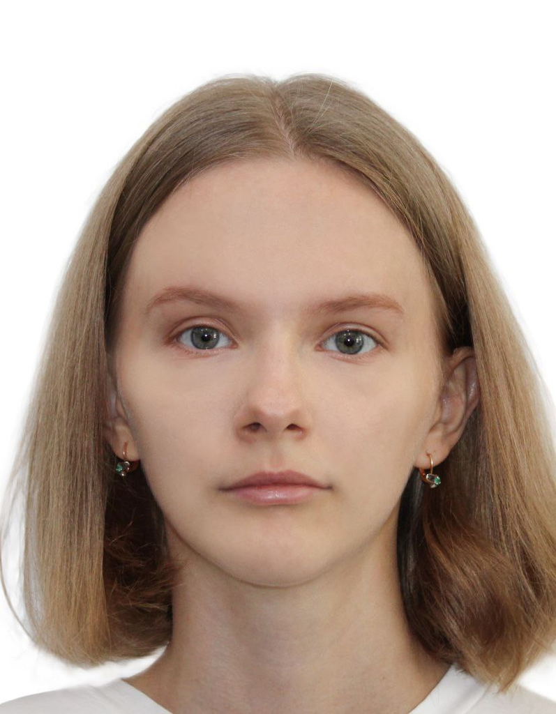

# Вводная часть

## Цели и задачи

- Добавить к своему сайту данные о себе
- Разместить фотографию владельца сайта
- Разместить краткое описание владельца сайта (Biography)
- Добавить информацию об интересах (Interests)
- Добавить информацию об образовании (Education)
- Сделать пост по прошедшей неделе
- Добавить пост на тему: Управление версиями. Git

## Техническая реализация проекта

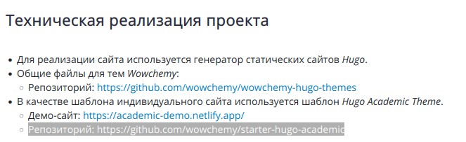

# Выполнение проекта

## 1 этап

- Переход в мой репозиторий
- Переход в codespase

[figure not shown]

## 2 этап

- Открываем content>authors>admin>_index.md и редактируем данные
- Добавление своей фотографии

[figure not shown]

## 3 этап 1 часть

- Открываем content>post и создаём новую папку, а в ней создаём файл index.md
- Добавляем в файл title, date, authors, tags и основной текст нашего поста по прошедшей неделе

[figure not shown]

## 3 этап 2 часть

- Повторяем прошлые действия для поста на тему: Управление версиями. Git
- Добавление фотографий к посту

[figure not shown]

## 4 этап

- Добавление описание изменений и фиксация этого
- Синхронизация изменений к нашему github repository

[figure not shown]

## 5 этап

- Переход в репозиторий aabarnova.github.io
- Публикация сайта

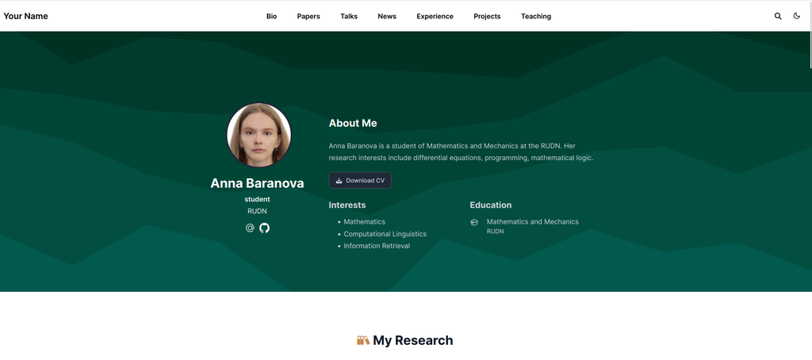

# Заключение